# IODS Course Project - Introduction to Open Data Science

Catarina Serafim

# Chapter 1 - Assignment 1

*This course will help me getting familiar with R, RStudio and GitHub. I hope I can learn some basics of data science and apply this knowledge on some of the data gathered during my PhD.*

[**My GitHub repository**](https://github.com/cdapalma/IODS-project.git)

Everything went smoothly with first assignment. Installation of the 3 programs went ok, and everything seems to be running. It is my first time working with GitHub and Rstudio. I have been trough some of the R Markdown syntax, and the language is quite strange for me. I didn’t quite understood what the Personal Access Token brings more in terms of connection between RStudio and GitHub, as you already are working with the shared IODS.

```r
date()
```

```
## [1] "Mon Nov 20 19:29:34 2023"
```

# Chapter 2 - Assignment 2

```r
date()
```

```
## [1] "Mon Nov 20 19:29:34 2023"
```

A full data set was provided for this exercise (https://www.mv.helsinki.fi/home/kvehkala/JYTmooc/JYTOPKYS3-data.txt). By reading the txt file and exploring the dimensions”dim()” and structure”str()” of the data we can see that the row data contains 183 observations and 64 variables.

We want to group the combination variables inside a specific group. The variables beginning with “D”, correspond to the deep questions, variables beginning with “SU” correspond to Surface questions, and variables begging with “ST”correspond to Strategic questions.

By combine multiple questions into combination variables, we have now 7 variables in total. From the 183 observations, we have excluded 17 observations, which are the the exam points marked as zero. so, in summary we have now 166 observations and 7 variables.

This was done inside the R script “create_learning_2014”. After arranging the data I have created the cvs file inside the folder ‘data’ which will be use for the analysis.

```r
library(dplyr)
library(GGally)
```

```r
library(ggplot2)
library(tidyverse)
#reading our csv file and explore a bit their content by seeing dimensions and structure.

output_learning2014 <- read.csv("data/output_learning2014.csv",sep = ",", header = T)

#dimensions of out data frame
dim(output_learning2014)
```

```
## [1] 166   7
```

```r
#structure
str(output_learning2014)
```

```
## 'data.frame':    166 obs. of  7 variables:
##  $ gender  : chr  "F" "M" "F" "M" ...
##  $ Age     : int  53 55 49 53 49 38 50 37 37 42 ...
##  $ attitude: num  3.7 3.1 2.5 3.5 3.7 3.8 3.5 2.9 3.8 2.1 ...
##  $ deep    : num  3.58 2.92 3.5 3.5 3.67 ...
##  $ stra    : num  3.38 2.75 3.62 3.12 3.62 ...
##  $ surf    : num  2.58 3.17 2.25 2.25 2.83 ...
##  $ Points  : int  25 12 24 10 22 21 21 31 24 26 ...
```

```r
#quick overview of the structure and values
head(output_learning2014)
```

```
##   gender Age attitude     deep  stra     surf Points
## 1      F  53      3.7 3.583333 3.375 2.583333     25
## 2      M  55      3.1 2.916667 2.750 3.166667     12
## 3      F  49      2.5 3.500000 3.625 2.250000     24
## 4      M  53      3.5 3.500000 3.125 2.250000     10
## 5      M  49      3.7 3.666667 3.625 2.833333     22
## 6      F  38      3.8 4.750000 3.625 2.416667     21
```

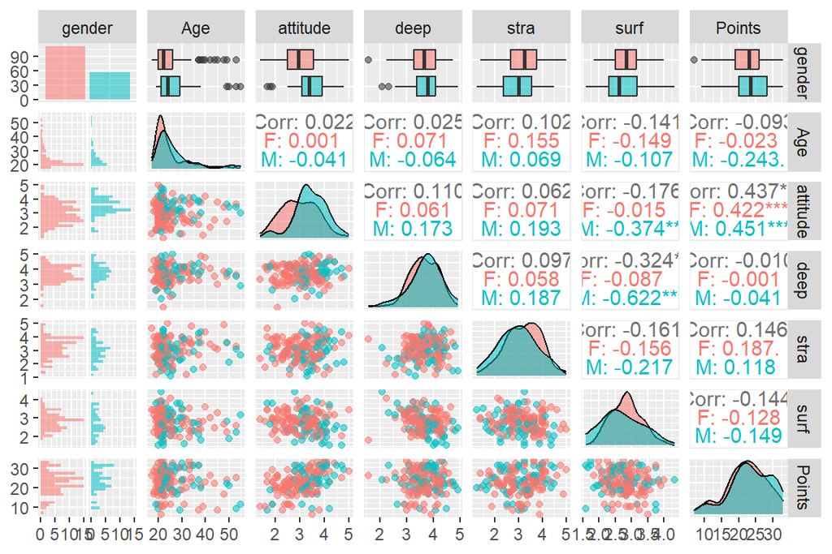

```r
#library(GGally)
#library(ggplot2)

#output_learning2014 <- read.csv("data/output_learning2014.csv",sep = ",", header = T)


# create a more advanced plot matrix with ggpairs()
#graphical overview of the data and show summaries of the variables in the data.

p <- ggpairs(output_learning2014, mapping = aes(col=gender, alpha=0.3),
             lower = list(combo = wrap("facethist", bins = 20)))

#color aesthetic (col) is mapped to the "gender" variable, and alpha is set to 0.3 for transparency.
p
```

When we use, not just pairs() but work toguether with the libraries GGally and ggplot2 we have a more detailed look at the variables, their distributions and relationships.

The ggpairs give us a graphical overview of our data and give us summaries of the variables. We can see from the matrix chart the distributions of ‘Age’, ‘attitude’, ‘deep’, ‘stra’, ‘surf’‘, and ’points’. For example, for the ‘Age’, we con observe that we have the pick of our distribution around the age of 20 for females.  
Also, we have the correlations between ‘Age’ vs ‘Attitude’, ‘Age’ vs ‘deep’, ‘Age’ vs ‘Stra’, ‘Age’ vs ‘surf’, ‘Age’ vs ‘Points’, ‘attitude’ vs ‘deep’, ‘attitude vs ’stra’, ‘attitude’ vs ‘surf’, ‘attitude’ vs ‘Points’, ‘deep’ vs ‘stra’, ‘deep’ vs ‘surf’, ‘deep’ vs ‘Points’, ‘stra’ vs ‘surf’, ‘stra’ vs ‘Points’, ‘surf’ vs ‘Points’.

Now we are creating the module for the regression asked in the exercise. I have chosen ‘attitude’, ‘deep’ and ‘stra’ as explanatory variables, and have fitted a regression model where exam points is the target variable.

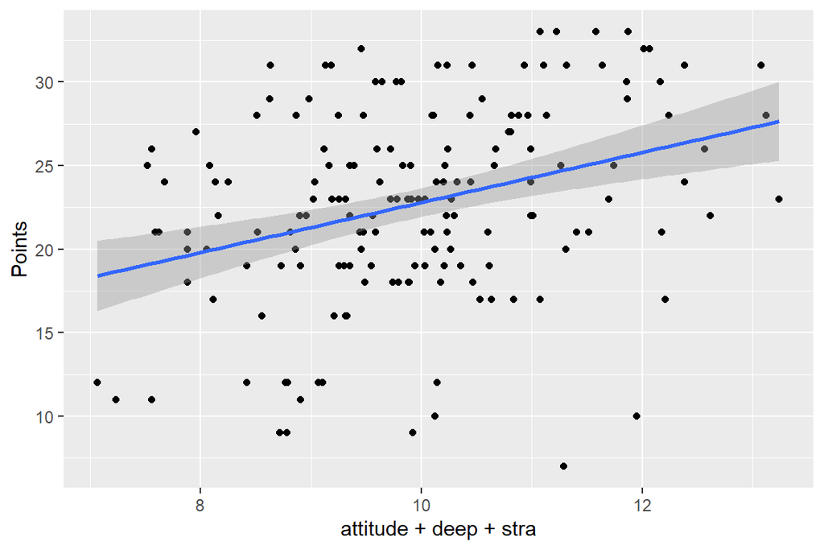

```r
#library(GGally)
#library(ggplot2)

#output_learning2014 <- read.csv("data/output_learning2014.csv",sep = ",", header = T)

#Points will be the target variable.
#explanatory variables will be attitude, deep and stra
#regression model is the following, taking in consideration the up comments

qplot(attitude + deep + stra, Points , data = output_learning2014) + geom_smooth(method = "lm")
```

```r
# fitting a linear model
model1 <- lm(Points ~ attitude + deep + stra, data = output_learning2014)

# printing my summary of the model
summary(model1)
```

```
##
## Call:
## lm(formula = Points ~ attitude + deep + stra, data = output_learning2014)
##
## Residuals:
##      Min       1Q   Median       3Q      Max
## -17.5239  -3.4276   0.5474   3.8220  11.5112
##
## Coefficients:
##             Estimate Std. Error t value Pr(>|t|)
## (Intercept)  11.3915     3.4077   3.343  0.00103 **
## attitude      3.5254     0.5683   6.203 4.44e-09 ***
## deep         -0.7492     0.7507  -0.998  0.31974
## stra          0.9621     0.5367   1.793  0.07489 .
## ---
## Signif. codes:  0 '***' 0.001 '**' 0.01 '*' 0.05 '.' 0.1 ' ' 1
##
## Residual standard error: 5.289 on 162 degrees of freedom
## Multiple R-squared:  0.2097, Adjusted R-squared:  0.195
## F-statistic: 14.33 on 3 and 162 DF,  p-value: 2.521e-08
```

I have removed the explanatory variable ‘deep’ from the code and fitted again the model.

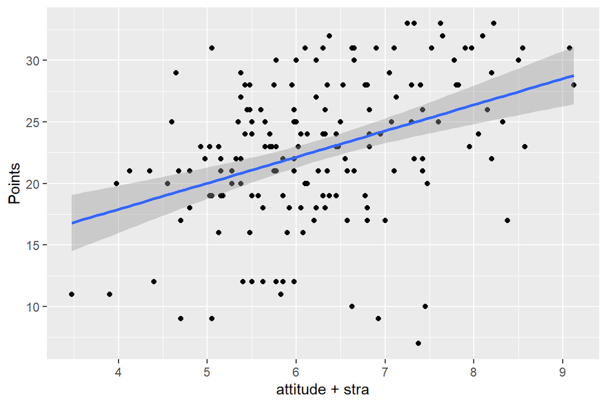

```r
#library(GGally)
#library(ggplot2)

#output_learning2014 <- read.csv("data/output_learning2014.csv",sep = ",", header = T)

#explanatory variables will be attitude and stra
#Points will the target variable.
#regression model is the following, taking in consideration the up comments

qplot(attitude + stra, Points , data = output_learning2014) + geom_smooth(method = "lm")
```

```r
# fitting a linear model
model2 <- lm(Points ~ attitude + stra, data = output_learning2014)

# print out again my summary of the model
summary(model2)
```

```
##
## Call:
## lm(formula = Points ~ attitude + stra, data = output_learning2014)
##
## Residuals:
##      Min       1Q   Median       3Q      Max
## -17.6436  -3.3113   0.5575   3.7928  10.9295
##
## Coefficients:
##             Estimate Std. Error t value Pr(>|t|)
## (Intercept)   8.9729     2.3959   3.745  0.00025 ***
## attitude      3.4658     0.5652   6.132 6.31e-09 ***
## stra          0.9137     0.5345   1.709  0.08927 .
## ---
## Signif. codes:  0 '***' 0.001 '**' 0.01 '*' 0.05 '.' 0.1 ' ' 1
##
## Residual standard error: 5.289 on 163 degrees of freedom
## Multiple R-squared:  0.2048, Adjusted R-squared:  0.1951
## F-statistic: 20.99 on 2 and 163 DF,  p-value: 7.734e-09
```

I have set up a 2x2 Grid for the next plots using the function par().

I have produce diagnostic plots using the plot() function with the which argument to specify which diagnostic plots i want, according with the assignment. In this case, which = c(1, 2, 5) will produce me Residuals vs Fitted values, Normal QQ-plot, and Residuals vs Leverage plots.

For the first one, residuals should be independent of each other. There should be no systematic pattern in the residuals over time or across observations. In our case, we see that the residuals are equally and randomly distributed around 0, with essentially no pattern. Also, overall we see that the spread of the residuals is roughly equal across the range of fitted values. As residuals are linearly distributed, variance is uniform.

A Normal Quantile-Quantile (QQ) plot of the residuals can be used to assess normality. The points on the QQ plot don’t deviate significantly from the diagonal line, which suggests are normally distributed.

With the residuals vs leverage plot We’re looking at how the spread of standardized residuals changes as the leverage The spread of standardized residuals shouldn’t change as a function of leverage. Our model tries to minimize the distance of the line from all the points. Points which are further from the line can sometimes have a greater influence over the plot and deleting them can change the model a lot. We can observe that we have more points concentrated on the left part of the plot, and some of the points close to the Cook’s distance which can mean that those observations are not exerting a high influence on the regression coefficients.

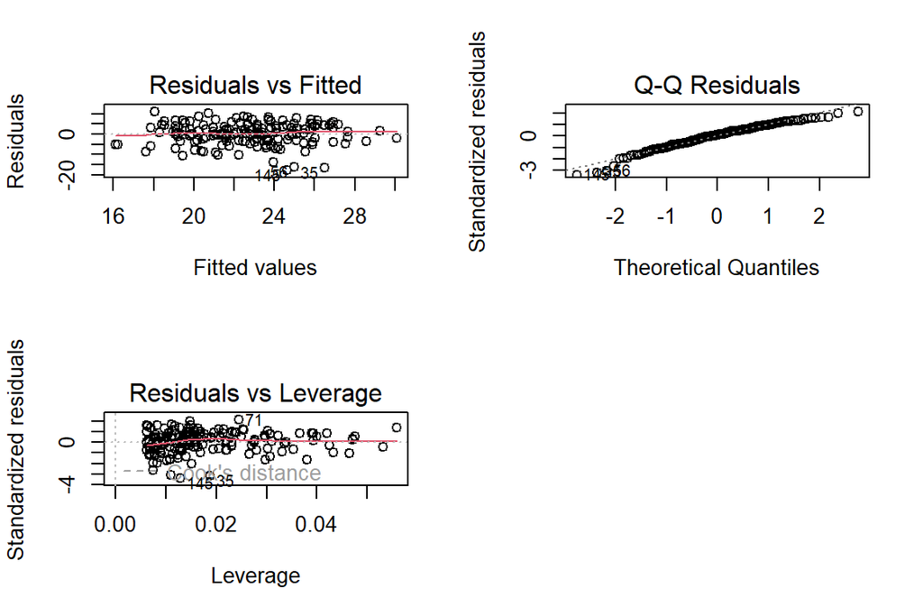

```r
#library(GGally)
#library(ggplot2)

#output_learning2014 <- read.csv("data/output_learning2014.csv",sep = ",", header = T)

#my grid
par(mfrow = c(2,2))

#draw of the diagnostic plots: Residuals vs Fitted values, Normal QQ-plot and Residuals vs Leverage.
plot(model2, which=c(1,2,5))
```

# Chapter 3 - Assignment 3

This data approach student achievement in secondary education of two Portuguese schools. The data include student grades, demographic, social and school related features) and it was collected by using school reports and questionnaires. Two datasets are provided regarding the performance in two distinct subjects: Mathematics (mat) and Portuguese language (por). In the R script ’ create_alc.R’ I have joined the two data sets using all other variables than “failures”, “paid”, “absences”, “G1”, “G2”, “G3” as (student) identifiers. At the end our data set has 370 observations and 35 variables.

Because we will use it for the analysis, one think important to understand is our logical column ‘high_use’, which was created in the wrangling exercise part. This column shows as TRUE when the average of the answers related to weekday and weekend alcohol consumption is > 2 and FALSE otherwise.

For the exercise I will choose some of the variables, which will be explained later above.

```r
library(tidyr)
library(readr)
library(dplyr)
library(ggplot2)


alc <- read.csv("data/alc.csv",sep = ",", header = T)

variables_names <- colnames(alc)
variables_names
```

```
##  [1] "school"     "sex"        "age"        "address"    "famsize"
##  [6] "Pstatus"    "Medu"       "Fedu"       "Mjob"       "Fjob"
## [11] "reason"     "guardian"   "traveltime" "studytime"  "schoolsup"
## [16] "famsup"     "activities" "nursery"    "higher"     "internet"
## [21] "romantic"   "famrel"     "freetime"   "goout"      "Dalc"
## [26] "Walc"       "health"     "failures"   "paid"       "absences"
## [31] "G1"         "G2"         "G3"         "alc_use"    "high_use"
```

```r
dim(alc)
```

```
## [1] 370  35
```

```r
str(alc)
```

```
## 'data.frame':    370 obs. of  35 variables:
##  $ school    : chr  "GP" "GP" "GP" "GP" ...
##  $ sex       : chr  "F" "F" "F" "F" ...
##  $ age       : int  18 17 15 15 16 16 16 17 15 15 ...
##  $ address   : chr  "U" "U" "U" "U" ...
##  $ famsize   : chr  "GT3" "GT3" "LE3" "GT3" ...
##  $ Pstatus   : chr  "A" "T" "T" "T" ...
##  $ Medu      : int  4 1 1 4 3 4 2 4 3 3 ...
##  $ Fedu      : int  4 1 1 2 3 3 2 4 2 4 ...
##  $ Mjob      : chr  "at_home" "at_home" "at_home" "health" ...
##  $ Fjob      : chr  "teacher" "other" "other" "services" ...
##  $ reason    : chr  "course" "course" "other" "home" ...
##  $ guardian  : chr  "mother" "father" "mother" "mother" ...
##  $ traveltime: int  2 1 1 1 1 1 1 2 1 1 ...
##  $ studytime : int  2 2 2 3 2 2 2 2 2 2 ...
```

[output cut: 21 more lines]

The variables that will be in interest to us are ‘goout’, which means going out with friends (numeric: from 1 - very low to 5 - very high), ‘failures’ which are the number of past class failures (numeric: n if 1<=n<3, else 4), ‘absences’ which are the number of school absences (numeric: from 0 to 93), ‘G3’ represents the final grade (numeric: from 0 to 20, output target).

For each variable we want to analyse its relationship with the alcohol consumption. So for each variable we can formulate a priori one personal hypothesis: Higher levels of going out with friends (‘goout’) might be associated with an increase in alcohol consumption. Students who go out more frequently may have higher alcohol consumption. Students with a higher number of past class failures (‘failures’) may exhibit higher alcohol consumption. A higher number of school absences (‘absences’) may be associated with higher alcohol consumption. Students who are frequently absent might have more opportunities for social activities, including alcohol consumption. There might be an inverse relationship between the final grade (‘G3’) and alcohol consumption. Students with lower grades might be more likely to engage in higher alcohol consumption.

```r
alc %>% group_by(failures) %>% summarise(count = n())
```

```
## # A tibble: 4 × 2
##   failures count
##      <int> <int>
## 1        0   325
## 2        1    24
## 3        2    17
## 4        3     4
```

```r
alc %>% group_by(absences) %>% summarise(count = n())
```

```
## # A tibble: 26 × 2
##    absences count
##       <int> <int>
##  1        0    63
##  2        1    50
##  3        2    56
##  4        3    38
##  5        4    35
##  6        5    22
##  7        6    21
##  8        7    12
##  9        8    20
## 10        9    11
## # ℹ 16 more rows
```

```r
alc %>% group_by(G3) %>% summarise(count = n())
```

```
## # A tibble: 18 × 2
##       G3 count
##    <int> <int>
##  1     0     2
##  2     2     1
##  3     3     1
##  4     4     6
##  5     5     5
##  6     6    21
##  7     7     5
##  8     8    26
##  9     9     7
## 10    10    63
## 11    11    25
## 12    12    78
## 13    13    25
## 14    14    38
## 15    15    16
## 16    16    37
## 17    17     7
## 18    18     7
```

```r
alc %>% group_by(goout) %>% summarise(count = n())
```

```
## # A tibble: 5 × 2
##   goout count
##   <int> <int>
## 1     1    22
## 2     2    97
## 3     3   120
## 4     4    78
## 5     5    53
```

```r
#alc %>%
#  group_by(high_use, sex) %>%
#  summarise(failures = median(failures))


#summary(alc$address)

#cross-tabulations


# Cross-tabulation of 'goout' with 'alc_use'
cross_tab_goout <- table(alc$goout, alc$high_use)
print("Cross-tabulation of 'goout' with 'high_use'")
```

```
## [1] "Cross-tabulation of 'goout' with 'high_use'"
```

```r
cross_tab_goout
```

```
##
##     FALSE TRUE
##   1    19    3
##   2    82   15
##   3    97   23
##   4    40   38
##   5    21   32
```

```r
# Cross-tabulation of 'failures' with 'alc_use'
cross_tab_failures <- table(alc$failures, alc$high_use)
print("Cross-tabulation of 'failures' with 'high_use'")
```

```
## [1] "Cross-tabulation of 'failures' with 'high_use'"
```

```r
cross_tab_failures
```

```
##
##     FALSE TRUE
##   0   238   87
##   1    12   12
##   2     8    9
##   3     1    3
```

```r
# Cross-tabulation of 'absences' with 'alc_use'
cross_tab_absences <- table(alc$absences, alc$high_use)
print("Cross-tabulation of 'absences' with 'high_use'")
```

```
## [1] "Cross-tabulation of 'absences' with 'high_use'"
```

```r
cross_tab_absences
```

```
##
##      FALSE TRUE
##   0     50   13
##   1     37   13
##   2     40   16
##   3     31    7
##   4     24   11
##   5     16    6
##   6     16    5
##   7      9    3
##   8     14    6
##   9      5    6
##   10     5    2
##   11     2    3
##   12     3    4
##   13     1    1
##   14     1    6
##   16     0    1
##   17     0    1
##   18     1    1
##   19     0    1
##   20     2    0
##   21     1    1
##   26     0    1
##   27     0    1
##   29     0    1
##   44     0    1
##   45     1    0
```

```r
# Cross-tabulation of 'G3' with 'alc_use'
cross_tab_G3 <- table(alc$G3, alc$high_use)
print("Cross-tabulation of 'G3' with 'high_use'")
```

```
## [1] "Cross-tabulation of 'G3' with 'high_use'"
```

```r
cross_tab_G3
```

```
##
##      FALSE TRUE
##   0      1    1
##   2      0    1
##   3      1    0
##   4      5    1
##   5      3    2
##   6     15    6
##   7      3    2
##   8     18    8
##   9      3    4
##   10    38   25
##   11    16    9
##   12    51   27
##   13    18    7
##   14    31    7
##   15    15    1
##   16    29    8
##   17     5    2
##   18     7    0
```

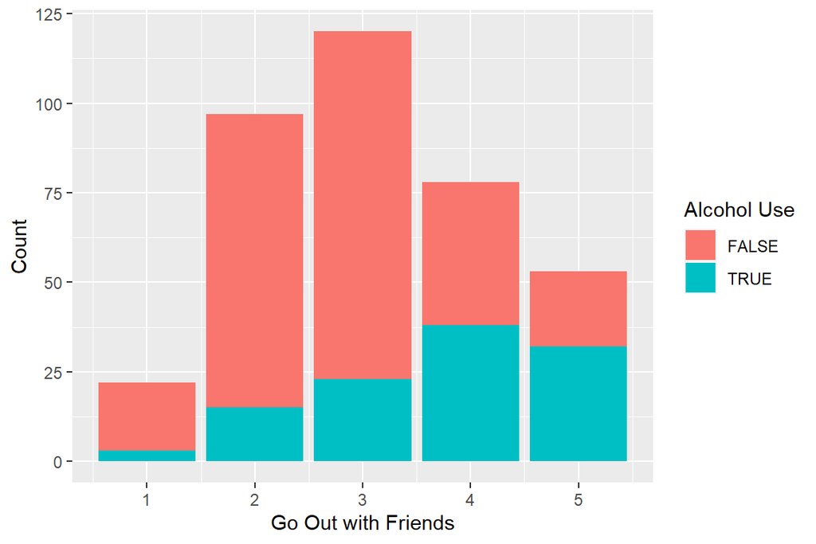

```r
#bar plots
# Bar plot for 'goout' and its relationship with 'alc_use'
ggplot(data=alc, aes(x = goout, fill = high_use)) +
  geom_bar() +
  labs(x = "Go Out with Friends", y = "Count", fill = "Alcohol Use")
```

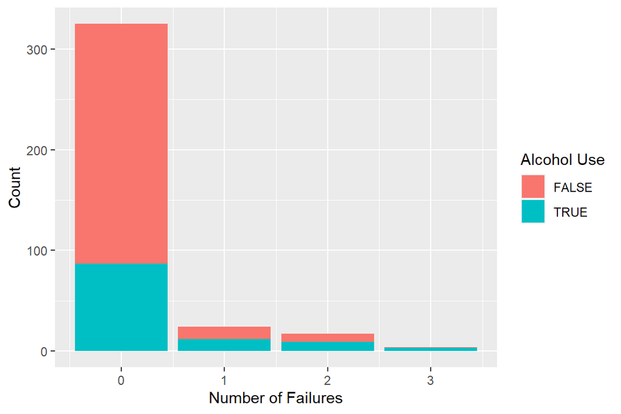

```r
# Bar plot for 'failures' and its relationship with 'alc_use'
ggplot(alc, aes(x = failures, fill = high_use)) +
  geom_bar() +
  labs(x = "Number of Failures", y = "Count", fill = "Alcohol Use")
```

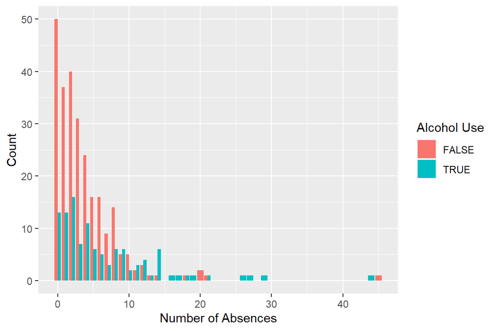

```r
#for the last two plots, I've tryed diferent way of ploting the bars

# Bar plot for 'absences' and its relationship with 'alc_use'
ggplot(alc, aes(x = absences, fill = high_use)) +
  geom_bar(position = "dodge", stat = "count") +
  labs(x = "Number of Absences", y = "Count", fill = "Alcohol Use")
```

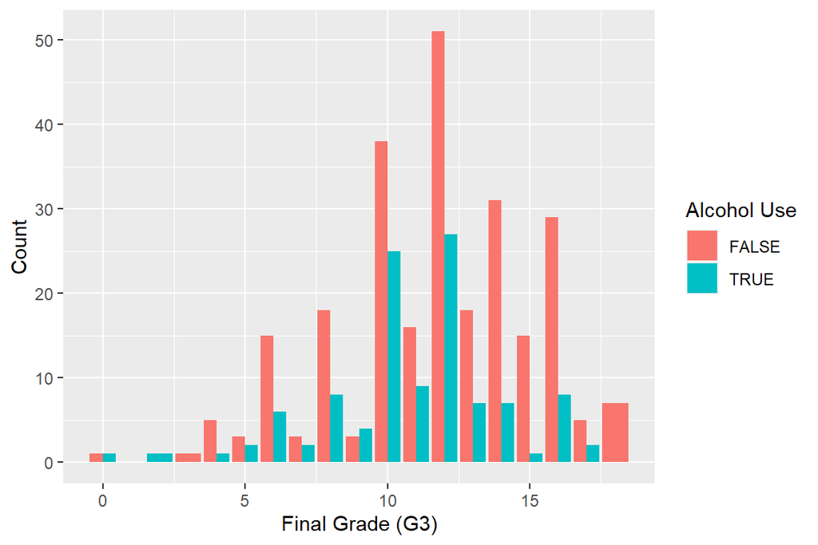

```r
# Bar plot for 'G3' and its relationship with 'alc_use'
ggplot(alc, aes(x = G3, fill = high_use)) +
  geom_bar(position = "dodge", stat = "count") +
  labs(x = "Final Grade (G3)", y = "Count", fill = "Alcohol Use")
```

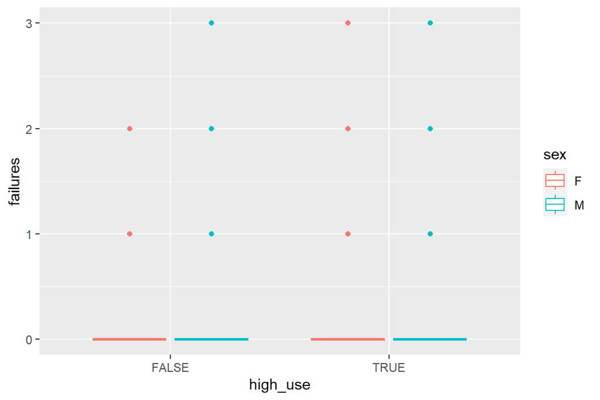

```r
#boxplots

g_failures <- ggplot(alc, aes(x = high_use, y = failures, col = sex))
g_failures + geom_boxplot() + ylab("failures")
```

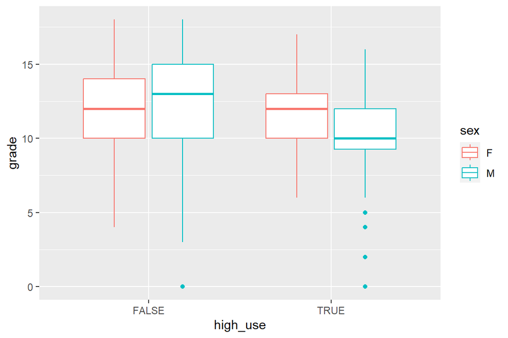

```r
g_g3 <- ggplot(alc, aes(x = high_use, y = G3, col = sex))
g_g3 + geom_boxplot() + ylab("grade")
```

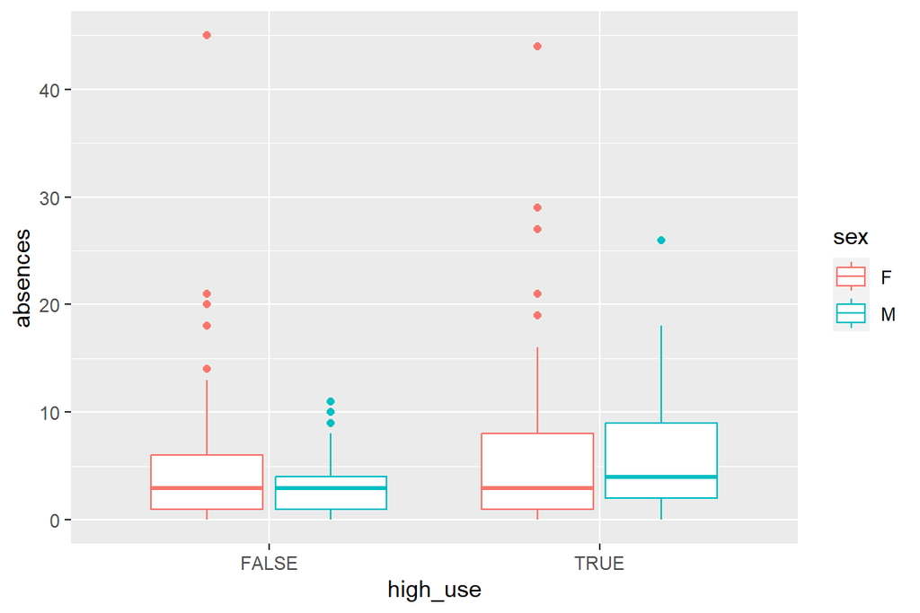

```r
g_absences <- ggplot(alc, aes(x = high_use, y = absences, col = sex))
g_absences + geom_boxplot() + ylab("absences")
```

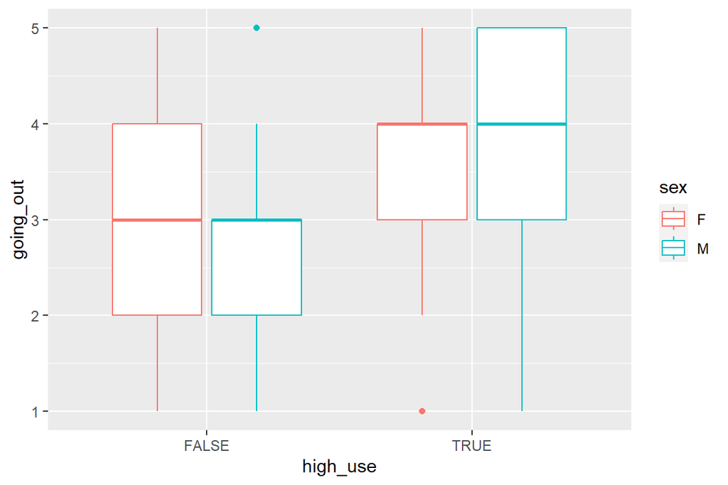

```r
g_goout <- ggplot(alc, aes(x = high_use, y = goout, col = sex))
g_goout + geom_boxplot() + ylab("going_out")
```

I’ve used logistic regression to explore the relationship between my variables and the high/low alcohol consumption variable as the target variable.

For the variable ‘failures’, for each one-unit increase in the number of failures, the response of the high/low alcohol consumption (target variable) increases by 0.52078. The p-value (0.028128 ) is less than 0.05, indicating that the coefficient for failures is statistically significant.

For absences, for each additional absence, the log-odds of the response variable increases by 0.07373. The p-value is also less than 0.05 (0.000958), indicating that the coefficient for absences is statistically significant.

For the final grade (G3), for each one-unit increase in the G3 variable, the response of the target variable decreases by 0.01612. Here, the p-value (0.699253) is greater than 0.05, indicating that the coefficient for G3 is not statistically significant. Therefore, the variable G3 is not contributing significantly to the model.

For the variable of going out with friends, for each one-unit increase in the goout variable, the response of the target variable increases by 0.69791.The z-value (5.874) corresponds to a very small p-value (4.25e-09), which is highly statistically significant.

The second part of the code fits a logistic regression model, extracts the coefficients, computes the odds ratios, calculates confidence intervals, and then prints out the odds ratios with their confidence intervals. The confint() function is used to obtain the confidence intervals for the coefficients, and the exp() function is applied to exponent the values. The cbind() function is used to combine the odds ratios and confidence intervals into a single matrix for printing.

For failures, for each unity increased in the number of failures, the odds of the response variable increases by a factor of 1.6833396. (In summa, an increase in the number of failures is associated with an increase in the odds of high alcohol use).The 95% confidence interval for the odds ratio is (1.062542815 - 2.7040414).

For absences, for each unit increased in the number of absences, the odds of the response variable increases by a factor of 1.0765213 (in summa, an increase in the number of absences is associated with a slight increase in the odds of high alcohol useHere). The 95% confidence interval for the odds ratio is 1.031833703 - 1.1275904. For the final grades variable the odds of the target variable is 0.9840135x the odds of the reference level. The 95% confidence interval is 0.906930755 - 1.0685440. For the variable of going out, the odds of the target variable is 2.0095429 x the odds of the reference level. The 95% confidence interval is 1.600845280 - 2.5531997.

Regarding the Intercept, the odds of the baseline level of the target variable is 0.0326675 x the odds of the reference level when all predictors are zero. This indicates a lower likelihood of high alcohol use for the reference level. The 95% confidence interval for the odds ratio is 0.007953009 - 0.1220042.

```r
# Explore the dataset
str(alc)
```

```
## 'data.frame':    370 obs. of  35 variables:
##  $ school    : chr  "GP" "GP" "GP" "GP" ...
##  $ sex       : chr  "F" "F" "F" "F" ...
##  $ age       : int  18 17 15 15 16 16 16 17 15 15 ...
##  $ address   : chr  "U" "U" "U" "U" ...
##  $ famsize   : chr  "GT3" "GT3" "LE3" "GT3" ...
##  $ Pstatus   : chr  "A" "T" "T" "T" ...
##  $ Medu      : int  4 1 1 4 3 4 2 4 3 3 ...
##  $ Fedu      : int  4 1 1 2 3 3 2 4 2 4 ...
##  $ Mjob      : chr  "at_home" "at_home" "at_home" "health" ...
##  $ Fjob      : chr  "teacher" "other" "other" "services" ...
##  $ reason    : chr  "course" "course" "other" "home" ...
##  $ guardian  : chr  "mother" "father" "mother" "mother" ...
##  $ traveltime: int  2 1 1 1 1 1 1 2 1 1 ...
##  $ studytime : int  2 2 2 3 2 2 2 2 2 2 ...
```

[output cut: 21 more lines]

```r
# Fit the logistic regression model
model <- glm(high_use ~ failures + absences + G3 + goout,
             data = alc,
             family = "binomial")
summary(model)
```

```
##
## Call:
## glm(formula = high_use ~ failures + absences + G3 + goout, family = "binomial",
##     data = alc)
##
## Coefficients:
##             Estimate Std. Error z value Pr(>|z|)
## (Intercept) -3.42137    0.69467  -4.925 8.43e-07 ***
## failures     0.52078    0.23720   2.195 0.028128 *
## absences     0.07373    0.02233   3.303 0.000958 ***
## G3          -0.01612    0.04171  -0.386 0.699253
## goout        0.69791    0.11881   5.874 4.25e-09 ***
## ---
## Signif. codes:  0 '***' 0.001 '**' 0.01 '*' 0.05 '.' 0.1 ' ' 1
##
## (Dispersion parameter for binomial family taken to be 1)
##
##     Null deviance: 452.04  on 369  degrees of freedom
## Residual deviance: 383.91  on 365  degrees of freedom
## AIC: 393.91
##
## Number of Fisher Scoring iterations: 4
```

```r
coef(model)
```

```
## (Intercept)    failures    absences          G3       goout
## -3.42137467  0.52077970  0.07373480 -0.01611567  0.69790726
```

```r
# compute odds ratios (OR)
OR <- coef(model) %>% exp

# compute confidence intervals (CI)
CI <- confint(model) %>% exp
# print out the odds ratios with their confidence intervals
result <- cbind(OR, CI)
print(result)
```

```
##                    OR       2.5 %    97.5 %
## (Intercept) 0.0326675 0.007953009 0.1220042
## failures    1.6833396 1.062542815 2.7040414
## absences    1.0765213 1.031833703 1.1275904
## G3          0.9840135 0.906930755 1.0685440
## goout       2.0095429 1.600845280 2.5531997
```

```r
#model2 <- glm(high_use ~ failures + absences + G3 + goout -1,  data = alc,  family = "binomial")
# summary(model2)
#coef(model2)
```

The next part, provides insights into the performance of your logistic regression model, including accuracy, proportions, and inaccuracy metrics.

The scatter plot visually represents the predicted probabilities against the actual values. The points are colored based on whether the prediction is above (TRUE) or below (FALSE) the threshold of 0.5.

I computed a 2x2 confusion matrix to compare actual values and predictions. The confusion matrix provides counts of true positives, true negatives, false positives, and false negatives. For example, there are 252 true negatives (actual: FALSE, predicted: FALSE) and 33 true positives (actual: TRUE, predicted: TRUE).

I’ve defined a loss function to compute the average number of wrong predictions. This indicates that if we predict all observations as 0 (using a threshold of 0.5), the average inaccuracy is 30%. also, if we predict all observations as 1 (using a threshold of 0.5), the average inaccuracy is 0.7 or 70%.

I’ve adjusted the code to change the prob argument by giving it the prediction probabilities in alc, which give us the indication that the average inaccuracy is 22.97% using the actual predicted probabilities from the model.

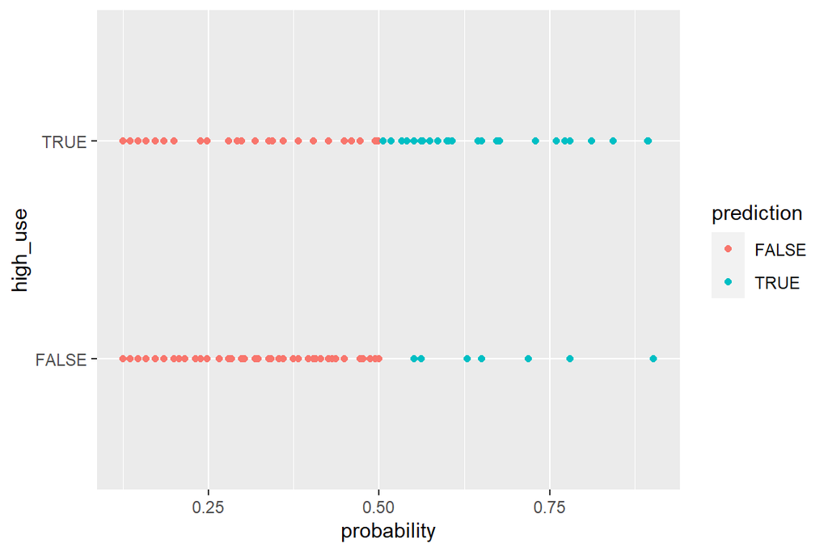

```r
m <- glm(high_use ~ sex + failures + absences, data = alc, family = "binomial")
alc <- mutate(alc, probability = predict(m, type = "response"))
alc <- mutate(alc, prediction = probability > 0.5)

# initialize a plot of 'high_use' versus 'probability' in 'alc'
g <- ggplot(alc, aes(x = probability, y = high_use))



# add the aesthetic element col = prediction and draw the plot again
g + geom_point(aes(col = prediction))
```

```r
# tabulate the target variable versus the predictions
table(high_use = alc$high_use, prediction = alc$prediction)
```

```
##         prediction
## high_use FALSE TRUE
##    FALSE   252    7
##    TRUE     78   33
```

```r
# adjust the code: use %>% to apply the prop.table() function on the output of table()
table(high_use = alc$high_use, prediction = alc$prediction) %>% prop.table()
```

```
##         prediction
## high_use      FALSE       TRUE
##    FALSE 0.68108108 0.01891892
##    TRUE  0.21081081 0.08918919
```

```r
# adjust the code: use %>% to apply the addmargins() function on the output of prop.table()
table(high_use = alc$high_use, prediction = alc$prediction) %>% prop.table() %>% addmargins()
```

```
##         prediction
## high_use      FALSE       TRUE        Sum
##    FALSE 0.68108108 0.01891892 0.70000000
##    TRUE  0.21081081 0.08918919 0.30000000
##    Sum   0.89189189 0.10810811 1.00000000
```

```r
#innacuracy
# define a loss function (mean prediction error)
loss_func <- function(class, prob) {
  n_wrong <- abs(class - prob) > 0.5
  mean(n_wrong)
}


# call loss_func to compute the average number of wrong predictions in the (training) data
loss_func(class = alc$high_use, prob = 0)
```

```
## [1] 0.3
```

```r
# adjust the code: change the prob argument in the loss function to prob = 1
loss_func(class = alc$high_use, prob = 1)
```

```
## [1] 0.7
```

```r
# adjust the code again: change the prob argument by giving it the prediction probabilities in alc (the column probability)
loss_func(class = alc$high_use, prob = alc$probability)
```

```
## [1] 0.2297297
```

Bonus and Super Bonus

The results suggest that the model’s performance is relatively consistent between leave-one-out cross-validation and 10-fold cross-validation. Both estimates of average inaccuracy are in a similar range, indicating that the model is making incorrect predictions for around 22-24% of the observations.

```r
library(boot)
m <- glm(high_use ~ sex + failures + absences, data = alc, family = "binomial")
alc <- mutate(alc, probability = predict(m, type = "response"))
alc <- mutate(alc, prediction = probability > 0.5)

loss_func <- function(class, prob) {
  n_wrong <- abs(class - prob) > 0.5
  mean(n_wrong)
}


loss_func(class = alc$high_use, prob = alc$probability)
```

```
## [1] 0.2297297
```

```r
# K-fold cross-validation
cv <- cv.glm(data = alc, cost = loss_func, glmfit = m, K = nrow(alc))

# average number of wrong predictions in the cross validation
cv$delta[1]
```

```
## [1] 0.2405405
```

```r
# 10-fold cross validation.
cv_10fold <- cv.glm(data = alc, cost = loss_func, glmfit = m, K = 10)
cv_10fold$delta[1]
```

```
## [1] 0.2459459
```

```r
# Fit the initial logistic regression model with a high number of predictors
full_model <- glm(high_use ~ .,
                  data = alc,
                  family = "binomial")
```

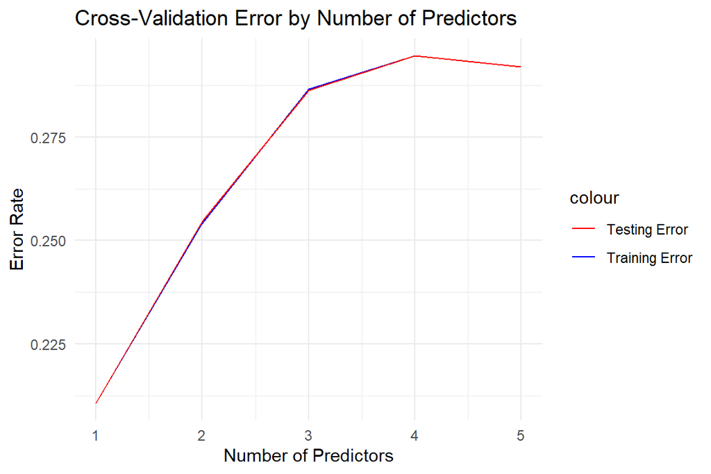

```r
# Extract the initial set of predictors
initial_predictors <- c("failures", "absences", "G3", "goout", "sex")

# Create a list to store the results
cv_results_list <- list()

# Perform cross-validation with different sets of predictors
for (i in length(initial_predictors):1) {
  current_predictors <- initial_predictors[1:i]

  # Fit the logistic regression model with the current set of predictors
  current_model <- glm(high_use ~ .,
                        data = select(alc, all_of(c(current_predictors, "high_use"))),
                        family = "binomial")

  # Perform K-fold cross-validation
  cv_results <- cv.glm(data = select(alc, all_of(c(current_predictors, "high_use"))),
                       cost = loss_func, glmfit = current_model, K = nrow(alc))

  # Store the results
  cv_results_list[[i]] <- cv_results
}

# Extract training and testing errors
training_errors <- sapply(cv_results_list, function(x) x$delta[1])
testing_errors <- sapply(cv_results_list, function(x) x$delta[2])

# Create a data frame for plotting
results_df <- data.frame(
  Predictors = length(initial_predictors):1,
  Training_Error = training_errors,
  Testing_Error = testing_errors
)

# Plot the trends of both training and testing errors by the number of predictors
ggplot(results_df, aes(x = Predictors)) +
  geom_line(aes(y = Training_Error, color = "Training Error")) +
  geom_line(aes(y = Testing_Error, color = "Testing Error")) +
  scale_color_manual(values = c("Training Error" = "blue", "Testing Error" = "red")) +
  labs(x = "Number of Predictors", y = "Error Rate", title = "Cross-Validation Error by Number of Predictors") +
  theme_minimal()
```